```python
import math
import matplotlib.pyplot as plt
import time
```

# Prime counting

Let's start with the goal of determining $\pi(n)$, the number of primes less than or equal to $n$.

## Trial division

One simple way to accomplish this task is to write a function `isPrime` and call it on each number $1\leq k \leq n$.

```python
def isPrime(n):
    return n > 1 and all(n % k != 0 for k in range(2, int(n**0.5 + 1)))

def primes(n):
    return [k for k in range(1, n+1) if isPrime(k)]

print(primes(30))
```

```
[2, 3, 5, 7, 11, 13, 17, 19, 23, 29]
```

Note that to determine if $n$ is prime, we only have to check for factors up to $\sqrt{n}$. This is because if $n=ab$, then either $a \leq \sqrt{n}$ or $b \leq \sqrt{n}$.

However, the code above still does quite a bit of redundant work. For example, if we know that $n$ is not divisible by $2$, we should not waste time checking whether it is divisible by any other even number. More generally, we only need to check for *prime* factors.

```python
def primesTrialDivision(n):
    output = list()
    sqrt_n = n**0.5
    for k in range(2, n+1):
        is_prime = True
        for p in output:
            if k % p == 0:
                is_prime = False
                break
            elif p > sqrt_n:
                break
        if is_prime:
            output.append(k)
    return output

print(primesTrialDivision(30))
```

```
[2, 3, 5, 7, 11, 13, 17, 19, 23, 29]
```

Is this new implementation really an improvement, or did we just make the code more complicated for nothing? Let's find out!

```python
def profileCode(fun, ns):
    times = list()
    for n in ns:
        start_time = time.time()
        fun(n)
        times.append(time.time() - start_time)
    return times
```

The answer appears to be yes - within the range we've examined, the improved program seems to be faster by a factor of 4 or so.

```
[0.16495609283447266, 0.3535478115081787, 0.9096810817718506, 2.3646597862243652, 6.282614707946777, 16.520813941955566] [0.04077601432800293, 0.09978485107421875, 0.25005412101745605, 0.635002851486206, 1.5773518085479736, 3.9334347248077393]
```

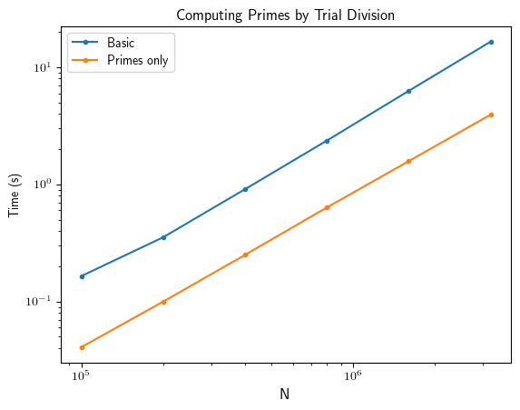

```python
ns = [100000 * 2**k for k in range(6)]

t1 = profileCode(primes, ns)
t2 = profileCode(primesTrialDivision, ns)
print(t1, t2)

plt.figure()
plt.loglog(ns, t1, marker='.')
plt.loglog(ns, t2, marker='.')
plt.title('Computing Primes by Trial Division')
plt.ylabel('Time (s)')
plt.xlabel('N', fontdict={'size': 12})
plt.legend(['Basic', 'Primes only'])
plt.show()
```

# Sieve of Eratosthenes

```
Trial division: 2.210603713989258 78498
```

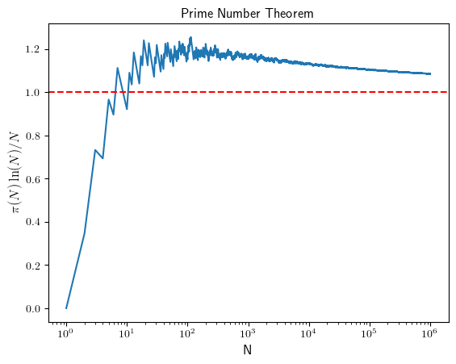

```python
import time

N = 1000000
start_time = time.time()
prime_counts = primeCounts(N)
duration = time.time() - start_time
print("Trial division:", duration, prime_counts[-1])

ns = range(1,N+1)
ratios = [prime_counts[n-1] * math.log(n) / n for n in ns]
plt.figure()
plt.semilogx(ns, ratios)
plt.axhline(y=1, color='r', linestyle='--')
plt.rcParams['text.usetex'] = True
plt.title('Prime Number Theorem')
plt.xlabel('N', fontdict={'size': 12})
plt.ylabel(r'$\pi(N)\ln(N)/N$', fontdict={'size': 12})
plt.show()
```

```python
def primeSieve(n):
    is_prime = [True] * (n+1)  # Start the list from n=0
    is_prime[0] = is_prime[1] = False
    for k in range(2, int(n**0.5) + 1):
        if is_prime[k]:
            for j in range(k*k, n+1, k):
                is_prime[j] = False
    return is_prime

def primeCountsSieve(n):
    count = 0
    output = list()
    is_prime = primeSieve(n)
    for k in range(1, n+1):
        if is_prime[k]:
            count += 1
        output.append(count)
    return output


start_time = time.time()
prime_counts_sieve = primeCountsSieve(N)
duration = time.time() - start_time
print("Sieve: ", duration, prime_counts_sieve[-1])
```

```
Sieve:  0.12377786636352539 78498
```

```python
def isPrime2(n):
    return all(n % k != 0 for k in range(2, int(n**0.5)+1))

def primeCounts2(n):
    count = 0
    output = list()
    for k in range(1, n+1):
        if isPrime(k):
            count += 1
        output.append(count)
    return output
```

```python
N = 1000000
start_time = time.time()
prime_counts = primeCounts2(N)
duration = time.time() - start_time
print("Trial division:", duration, prime_counts[-1])
```

```
Trial division: 2.199262857437134 78498
```